# Análisis Exploratorio de Datos

# Introducción

El análisis exploratorio de datos es una herramienta que nos ayudan a organizar la información de una base para detectar algún patrón de comportamiento de los parámetros de interés. Con el uso de la función modificada `MYEDA`. En el presente informe realizaremos un análisis exploratorio de las varibales cuantitativas `Tiempo_Servicio_seg`y `Monto`, del mismo modo es importante hacer un análisis más profundo y esto es tratando la variable `Sucursal`.

# Base

Se procede a cargar la base proporcionada

```
##  [1] "ID_Sucursal"         "Cajero"              "ID_Transaccion"
##  [4] "Transaccion"         "Tiempo_Servicio_seg" "Satisfaccion"
##  [7] "Monto"               "Sucursal"            "Nuevo_Sistema"
## [10] "Edad"                "Sexo"                "Nivel_Formacion"
## [13] "Anio.experiencia"
```

# Análisis exploratorio de la Base

A continuación vamos a realiza r un resumen breve de las variables y de la base

```r
str(data_1)
```

```
## 'data.frame':    24299 obs. of  13 variables:
##  $ ID_Sucursal        : num  62 62 62 62 62 62 62 62 62 62 ...
##  $ Cajero             : Factor w/ 27 levels "56","63","70",..: 23 23 23 23 23 23 23 23 23 23 ...
##  $ ID_Transaccion     : Factor w/ 3 levels "10","2","3": 2 2 2 2 2 2 2 2 2 2 ...
##  $ Transaccion        : Factor w/ 3 levels "Cobrar cheque (Cta del Bco)",..: 2 2 2 2 2 2 2 2 2 2 ...
##  $ Tiempo_Servicio_seg: num  311 156 248 99 123 172 140 247 183 91 ...
##  $ Satisfaccion       : Ord.factor w/ 5 levels "Muy Malo"<"Malo"<..: 5 2 3 3 5 4 3 4 5 5 ...
##  $ Monto              : num  17507 4586 18734 5268 5779 ...
##  $ Sucursal           : Factor w/ 5 levels "Alborada","Centro",..: 4 4 4 4 4 4 4 4 4 4 ...
##  $ Nuevo_Sistema      : Factor w/ 2 levels "No","Si": 1 1 1 1 1 1 1 1 1 1 ...
##  $ Edad               : num  42 42 42 42 42 42 42 42 42 42 ...
##  $ Sexo               : Factor w/ 2 levels "F","M": 1 1 1 1 1 1 1 1 1 1 ...
##  $ Nivel_Formacion    : Factor w/ 4 levels "Bachiller","Tecnologia",..: 1 1 1 1 1 1 1 1 1 1 ...
##  $ Anio.experiencia   : num  24 24 24 24 24 24 24 24 24 24 ...
```

```r
summary(data_1)
```

```
##   ID_Sucursal        Cajero      ID_Transaccion
##  Min.   : 62.0   3983   : 4280   10: 5407
##  1st Qu.: 85.0   472    : 2764   2 : 3005
##  Median : 85.0   3678   : 1962   3 :15887
##  Mean   :208.1   357    : 1832
##  3rd Qu.:443.0   2503   : 1578
##  Max.   :586.0   4208   : 1471
##                  (Other):10412
##                       Transaccion    Tiempo_Servicio_seg    Satisfaccion
##  Cobrar cheque (Cta del Bco): 5407   Min.   :  18.13     Muy Malo :3009
##  Cobro/Pago (Cta externa)   : 3005   1st Qu.:  75.69     Malo     :4474
##  Deposito                   :15887   Median : 122.45     Regular  :4639
##                                      Mean   : 155.58     Bueno    :5915
##                                      3rd Qu.: 197.73     Muy Bueno:6262
##                                      Max.   :1602.70
##
##      Monto                Sucursal     Nuevo_Sistema      Edad
##  Min.   :    1   Alborada     : 3329   No: 4736      Min.   :22.00
##  1st Qu.: 5856   Centro       :12044   Si:19563      1st Qu.:26.00
##  Median :11494   Mall del Sol : 4190                 Median :32.00
##  Mean   :11550   Riocentro Sur: 2838                 Mean   :33.45
##  3rd Qu.:17248   Via Daule    : 1898                 3rd Qu.:35.00
##  Max.   :23209                                       Max.   :55.00
##
##  Sexo          Nivel_Formacion  Anio.experiencia
##  F:17746   Bachiller   :10952   Min.   : 2.00
##  M: 6553   Tecnologia  : 1723   1st Qu.: 6.00
##            Tercer nivel: 4266   Median : 7.00
##            Univ Incom. : 7358   Mean   :10.92
##                                 3rd Qu.:16.00
##                                 Max.   :35.00
##
```

## Análisis exploratorio de la variable Tiempo_Servicio_seg

```r
source("funciones.R")
  data_1%>% summarise_at(vars(Tiempo_Servicio_seg),
                              funs(MEDIA= mean(., na.rm=TRUE),
                                   VARIANZA= var(., na.rm = TRUE),
                                   RIQ=IQR(., na.rm = TRUE),
                                   RANGO=diff(range(., na.rm = TRUE)),
                                   CANTIDAD= n()))
```

```
##    MEDIA VARIANZA      RIQ    RANGO CANTIDAD
## 1 155.58 14402.27 122.0393 1584.567    24299
```

```
## [1] "data_1$Tiempo_Servicio_seg"
```

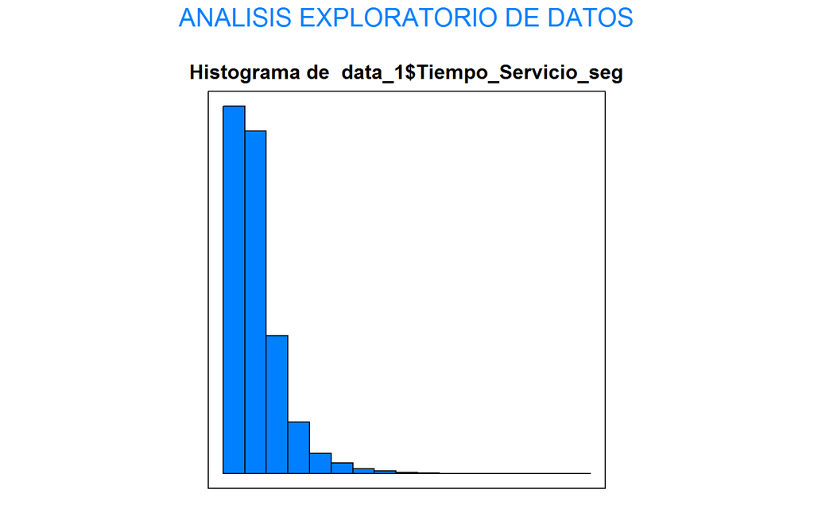

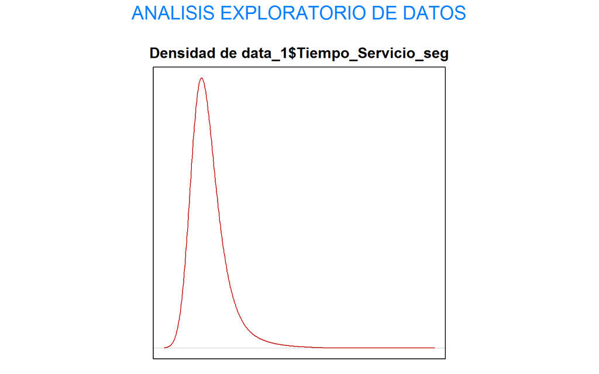

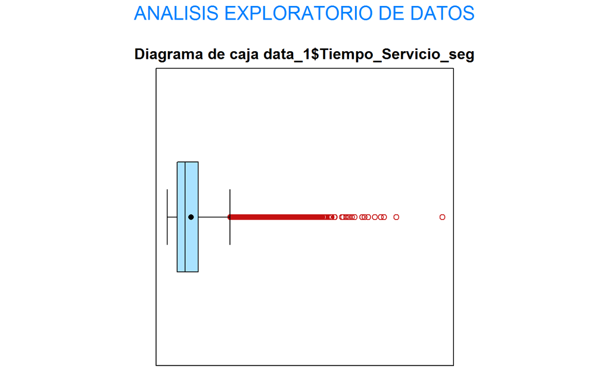

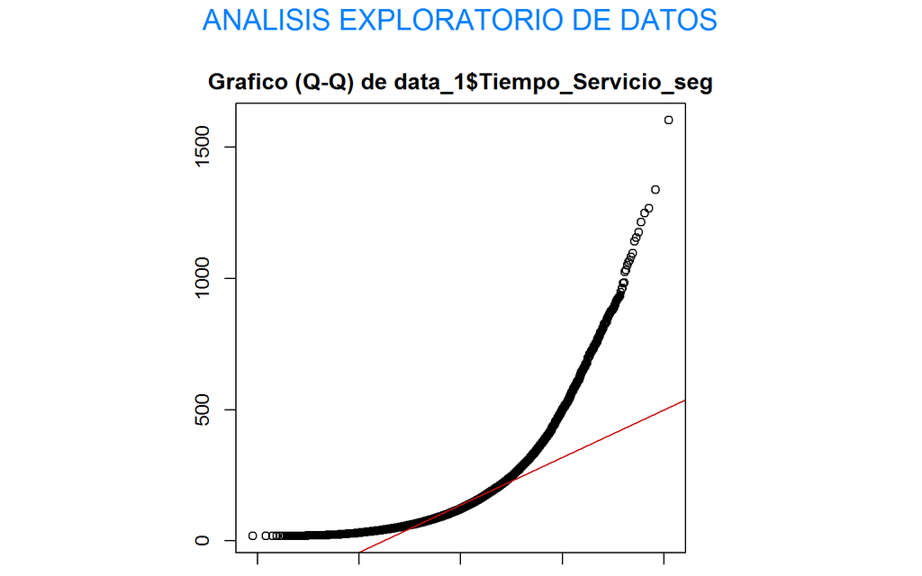

```r
  eda_tiempo<-MYEDA(data_1$Tiempo_Servicio_seg,plot=T)
```

```r
library(kableExtra)
kable(eda_tiempo$TOT) %>%
  kable_styling(bootstrap_options = c("striped", "hover", "condensed", "responsive"))
```

|  | x |
| --- | --- |
| Tamano(n) | 24299.000 |
| Perdidos | 0.000 |
| Minimo | 18.132 |
| 1er Cuartil | 75.688 |
| Media | 155.580 |
| Mediana | 122.452 |
| Media Recortada | 141.923 |
| 3er cuartil | 197.733 |
| Max. | 1602.698 |
| Desviacion Estandar | 120.009 |
| Varianza | 14402.270 |
| Error Estandar | 0.770 |
| Rango Intercuartilico | 122.045 |
| Rango | 1584.566 |
| Kurtosis | 9.250 |
| Skewness | 2.360 |
| Lillie p-val | 0.000 |

Gracias a este análisis podemos darnos cuenta que esta varible tratada no sigue una distribución normal, como podemos ver en el histograma y en el resultado de lillie p-val ya que existen muchos valores atípicos

### Análisis para la variable Sucursal

```r
  dt<-data_1 %>%  group_by(Sucursal) %>% summarise_at(vars(Tiempo_Servicio_seg),
                                              funs(MEDIA= mean(., na.rm=TRUE),
                                                   VARIANZA= var(., na.rm = TRUE),
                                                  RIQ=IQR(., na.rm = TRUE),
                                                  RANGO=diff(range(., na.rm = TRUE)),
                                                  CANTIDAD= n()))
  kable(dt) %>%
  kable_styling(bootstrap_options = c("striped", "hover", "condensed", "responsive"))
```

| Sucursal | MEDIA | VARIANZA | RIQ | RANGO | CANTIDAD |
| --- | --- | --- | --- | --- | --- |
| Alborada | 182.62714 | 17115.236 | 137.9682 | 1060.985 | 3329 |
| Centro | 166.39547 | 14545.074 | 123.1317 | 1584.567 | 12044 |
| Mall del Sol | 181.01157 | 17798.132 | 137.5585 | 1188.799 | 4190 |
| Riocentro Sur | 89.39253 | 3354.518 | 62.0000 | 502.000 | 2838 |
| Via Daule | 82.33456 | 2413.306 | 54.7500 | 360.000 | 1898 |

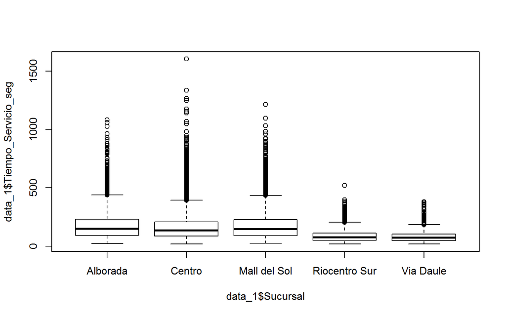

```r
boxplot(data_1$Tiempo_Servicio_seg ~ data_1$Sucursal)
```

Vemos que el problema por la existencia de muchos datos atípicos sigue por lo que se hace una transformación para obtener un mejor resultado

```r
data_1 <- data_1 %>% mutate(LTS=log(Tiempo_Servicio_seg))
```

| Sucursal | MEDIA | VARIANZA | RIQ | RANGO | CANTIDAD |
| --- | --- | --- | --- | --- | --- |
| Alborada | 4.994996 | 0.4247459 | 0.9077142 | 3.940841 | 3329 |
| Centro | 4.899640 | 0.4294440 | 0.8941933 | 4.481778 | 12044 |
| Mall del Sol | 4.975122 | 0.4448651 | 0.9245359 | 3.905984 | 4190 |
| Riocentro Sur | 4.312181 | 0.3623074 | 0.8177099 | 3.261935 | 2838 |
| Via Daule | 4.253752 | 0.3169824 | 0.7610889 | 2.944439 | 1898 |

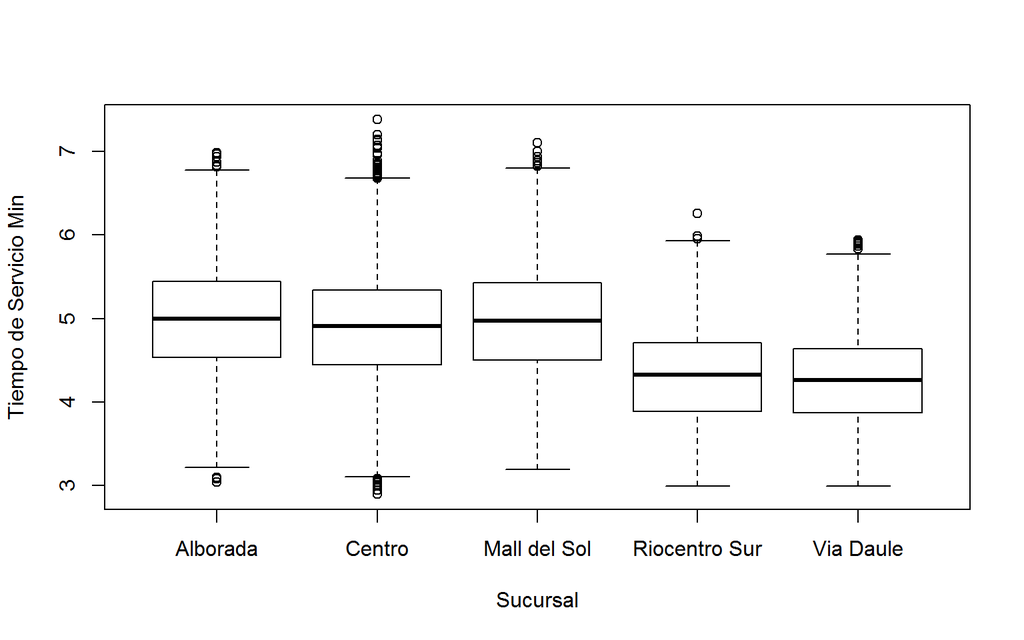

### Análisis Exploratorio por Sucursal (nueva variable)

Gracias a las transformación nos ayudará para realizar el análisis exploratorio con la función MYEDA

```
## [1] "suc_Riocentro_sur$TRANS"
```

|  | x |
| --- | --- |
| Tamano(n) | 2838.0000 |
| Perdidos | 0.0000 |
| Minimo | 2.9960 |
| 1er Cuartil | 3.8920 |
| Media | 4.3120 |
| Mediana | 4.3310 |
| Media Recortada | 4.3080 |
| 3er cuartil | 4.7100 |
| Max. | 6.2580 |
| Desviacion Estandar | 0.6020 |
| Varianza | 0.3620 |
| Error Estandar | 0.0110 |
| Rango Intercuartilico | 0.8180 |
| Rango | 3.2620 |
| Kurtosis | -0.3240 |
| Skewness | 0.0360 |
| Lillie p-val | 0.0016 |

```
## [1] "suc_Centro$TRANS"
```

|  | x |
| --- | --- |
| Tamano(n) | 12044.0000 |
| Perdidos | 0.0000 |
| Minimo | 2.8980 |
| 1er Cuartil | 4.4450 |
| Media | 4.9000 |
| Mediana | 4.9100 |
| Media Recortada | 4.8970 |
| 3er cuartil | 5.3390 |
| Max. | 7.3790 |
| Desviacion Estandar | 0.6550 |
| Varianza | 0.4290 |
| Error Estandar | 0.0060 |
| Rango Intercuartilico | 0.8940 |
| Rango | 4.4810 |
| Kurtosis | -0.2050 |
| Skewness | 0.0280 |
| Lillie p-val | 0.0033 |

```
## [1] "suc_Alborada$TRANS"
```

|  | x |
| --- | --- |
| Tamano(n) | 3329.0000 |
| Perdidos | 0.0000 |
| Minimo | 3.0460 |
| 1er Cuartil | 4.5350 |
| Media | 4.9950 |
| Mediana | 4.9980 |
| Media Recortada | 4.9920 |
| 3er cuartil | 5.4440 |
| Max. | 6.9870 |
| Desviacion Estandar | 0.6520 |
| Varianza | 0.4250 |
| Error Estandar | 0.0110 |
| Rango Intercuartilico | 0.9090 |
| Rango | 3.9410 |
| Kurtosis | -0.2060 |
| Skewness | 0.0350 |
| Lillie p-val | 0.2271 |

```
## [1] "suc_Mall_del_sol$TRANS"
```

|  | x |
| --- | --- |
| Tamano(n) | 4190.0000 |
| Perdidos | 0.0000 |
| Minimo | 3.1950 |
| 1er Cuartil | 4.5040 |
| Media | 4.9750 |
| Mediana | 4.9720 |
| Media Recortada | 4.9710 |
| 3er cuartil | 5.4290 |
| Max. | 7.1010 |
| Desviacion Estandar | 0.6670 |
| Varianza | 0.4450 |
| Error Estandar | 0.0100 |
| Rango Intercuartilico | 0.9250 |
| Rango | 3.9060 |
| Kurtosis | -0.2780 |
| Skewness | 0.0670 |
| Lillie p-val | 0.1625 |

```
## [1] "suc_Via_Daule$TRANS"
```

|  | x |
| --- | --- |
| Tamano(n) | 1898.0000 |
| Perdidos | 0.0000 |
| Minimo | 2.9960 |
| 1er Cuartil | 3.8710 |
| Media | 4.2540 |
| Mediana | 4.2630 |
| Media Recortada | 4.2530 |
| 3er cuartil | 4.6350 |
| Max. | 5.9400 |
| Desviacion Estandar | 0.5630 |
| Varianza | 0.3170 |
| Error Estandar | 0.0130 |
| Rango Intercuartilico | 0.7640 |
| Rango | 2.9440 |
| Kurtosis | -0.2840 |
| Skewness | -0.0150 |
| Lillie p-val | 0.0049 |

```
## $`ati_Riocentro_sur.Cantidad de Atipicos`
## [1] 3
##
## $`ati_Centro.Cantidad de Atipicos`
## [1] 38
##
## $`ati_alborada.Cantidad de Atipicos`
## [1] 9
##
## $`ati_mall.Cantidad de Atipicos`
## [1] 8
##
## $`ati_via_daule.Cantidad de Atipicos`
## [1] 6
```

#### Análisis sucursal Centro

Dada que la sucursal Centro presenta el mayor número de atípicios analizaremos las variables dentro de la ella

```r
 suc<-suc_Centro%>% group_by(Cajero,Sexo,Anio.experiencia,Edad,Nivel_Formacion) %>%
    summarise(Tiempo_min_prom=mean(Tiempo_Servicio_seg)/60,
              Transaccciones=n()) %>%
    kable()%>%
    kable_styling(bootstrap_options = c("striped","hover", "condensed", "responsive" ))
```

##### Análisis exploratorio de cajero más eficiente

```r
source("funciones.R")
suc_Centro_cajero3983 <- suc_Centro[suc_Centro$Cajero=="3983",]
eda1<-MYEDA(suc_Centro_cajero3983$TRANS)
```

```
## [1] "suc_Centro_cajero3983$TRANS"
```

```r
eda1[1] %>%
kable() %>%
kable_styling(bootstrap_options = c("striped","hover", "condensed", "responsive" ))
```

|  | x |
| --- | --- |
| Tamano(n) | 4280.0000 |
| Perdidos | 0.0000 |
| Minimo | 2.8980 |
| 1er Cuartil | 4.4110 |
| Media | 4.8470 |
| Mediana | 4.8580 |
| Media Recortada | 4.8450 |
| 3er cuartil | 5.2770 |
| Max. | 7.3790 |
| Desviacion Estandar | 0.6380 |
| Varianza | 0.4070 |
| Error Estandar | 0.0100 |
| Rango Intercuartilico | 0.8660 |
| Rango | 4.4810 |
| Kurtosis | -0.1300 |
| Skewness | 0.0170 |
| Lillie p-val | 0.1018 |

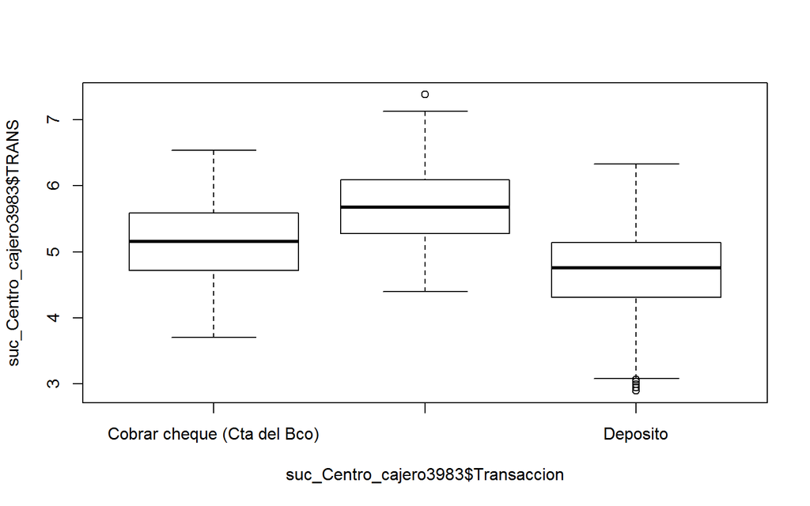

```r
boxplot(suc_Centro_cajero3983$TRANS ~
          suc_Centro_cajero3983$Transaccion)
```

De este resultado, se puede observar menos inconsistencias gracias a la transformación realizada en la variable `Tiempo_Servicio_seg` valiendonos de la variable transacción.

## Análisis exploratorio de la variable Monto

```r
source("funciones.R")
  data_1%>% summarise_at(vars(Monto),
                              funs(MEDIA= mean(., na.rm=TRUE),
                                   VARIANZA= var(., na.rm = TRUE),
                                   RIQ=IQR(., na.rm = TRUE),
                                   RANGO=diff(range(., na.rm = TRUE)),
                                   CANTIDAD= n()))
```

```
##     MEDIA VARIANZA   RIQ RANGO CANTIDAD
## 1 11549.8 44225877 11391 23208    24299
```

```
## [1] "data_1$Monto"
```

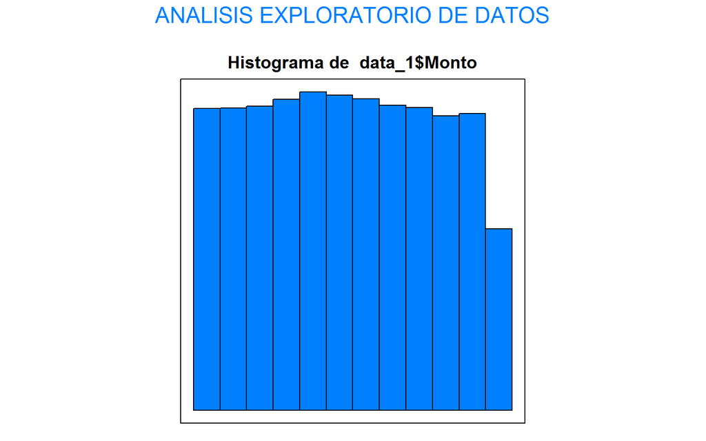

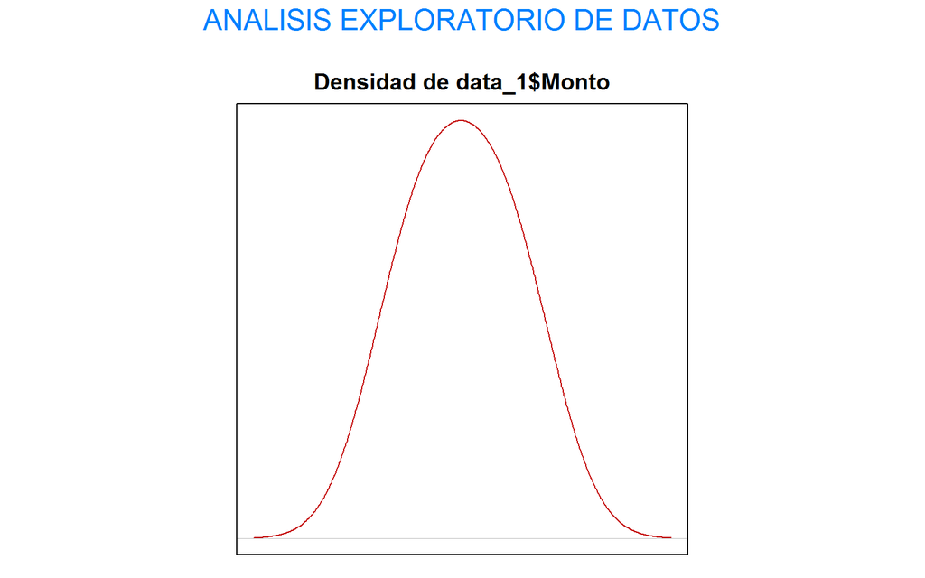

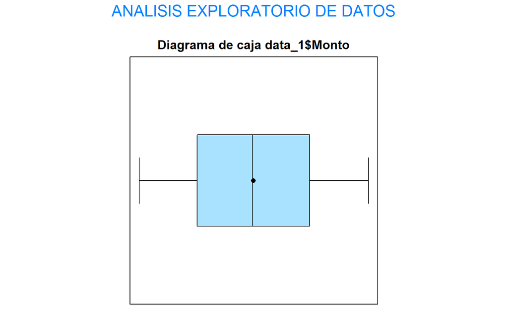

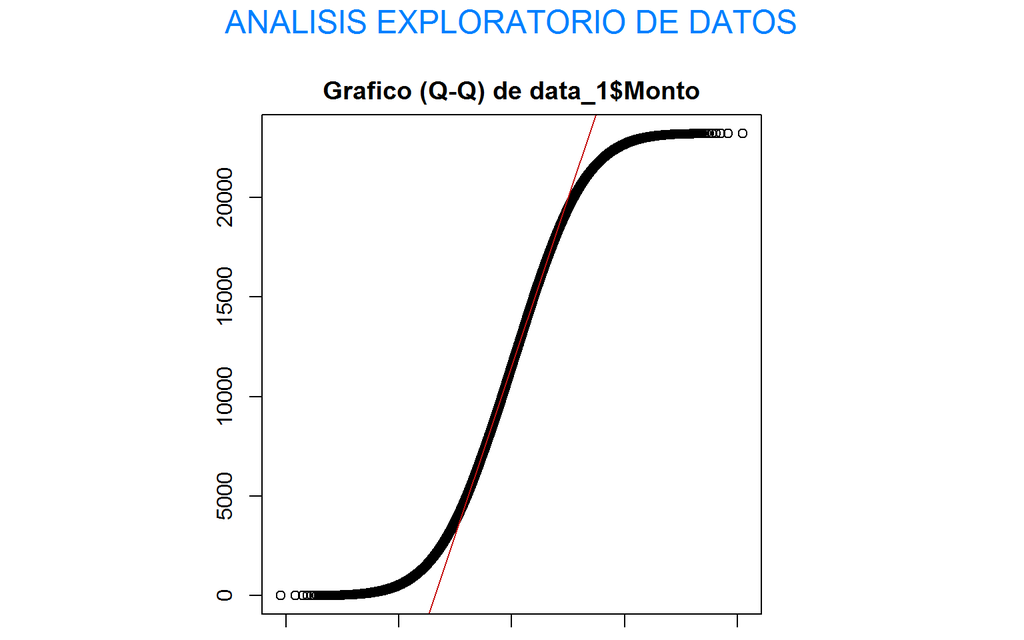

```r
  eda_monto<-MYEDA(data_1$Monto,plot=T)
```

```r
kable(eda_monto$TOT) %>%
  kable_styling(bootstrap_options = c("striped", "hover", "condensed", "responsive"))
```

|  | x |
| --- | --- |
| Tamano(n) | 24299.000 |
| Perdidos | 0.000 |
| Minimo | 1.000 |
| 1er Cuartil | 5856.000 |
| Media | 11549.804 |
| Mediana | 11494.000 |
| Media Recortada | 11543.679 |
| 3er cuartil | 17248.000 |
| Max. | 23209.000 |
| Desviacion Estandar | 6650.254 |
| Varianza | 44225876.941 |
| Error Estandar | 42.662 |
| Rango Intercuartilico | 11392.000 |
| Rango | 23208.000 |
| Kurtosis | -1.177 |
| Skewness | 0.015 |
| Lillie p-val | 0.000 |

### Análisis exploratorio por Sucursal

```
## [1] "suc_Riocentro_sur$Monto"
```

|  | x |
| --- | --- |
| Tamano(n) | 2838.000 |
| Perdidos | 0.000 |
| Minimo | 7.000 |
| 1er Cuartil | 4583.250 |
| Media | 10648.702 |
| Mediana | 9705.500 |
| Media Recortada | 10545.408 |
| 3er cuartil | 16399.500 |
| Max. | 23204.000 |
| Desviacion Estandar | 7016.236 |
| Varianza | 49227568.989 |
| Error Estandar | 131.704 |
| Rango Intercuartilico | 11816.250 |
| Rango | 23197.000 |
| Kurtosis | -1.173 |
| Skewness | 0.274 |
| Lillie p-val | 0.000 |

```
## [1] "suc_Centro$Monto"
```

|  | x |
| --- | --- |
| Tamano(n) | 12044.000 |
| Perdidos | 0.000 |
| Minimo | 2.000 |
| 1er Cuartil | 6238.250 |
| Media | 11675.064 |
| Mediana | 11737.500 |
| Media Recortada | 11684.722 |
| 3er cuartil | 17239.750 |
| Max. | 23209.000 |
| Desviacion Estandar | 6534.237 |
| Varianza | 42696248.230 |
| Error Estandar | 59.540 |
| Rango Intercuartilico | 11001.500 |
| Rango | 23207.000 |
| Kurtosis | -1.145 |
| Skewness | -0.029 |
| Lillie p-val | 0.000 |

```
## [1] "suc_Alborada$Monto"
```

|  | x |
| --- | --- |
| Tamano(n) | 3329.000 |
| Perdidos | 0.000 |
| Minimo | 1.000 |
| 1er Cuartil | 6386.000 |
| Media | 11855.005 |
| Mediana | 12000.000 |
| Media Recortada | 11883.780 |
| 3er cuartil | 17504.500 |
| Max. | 23196.000 |
| Desviacion Estandar | 6537.924 |
| Varianza | 42744443.921 |
| Error Estandar | 113.314 |
| Rango Intercuartilico | 11118.500 |
| Rango | 23195.000 |
| Kurtosis | -1.147 |
| Skewness | -0.080 |
| Lillie p-val | 0.000 |

```
## [1] "suc_Mall_del_sol$Monto"
```

|  | x |
| --- | --- |
| Tamano(n) | 4190.000 |
| Perdidos | 0.000 |
| Minimo | 3.000 |
| 1er Cuartil | 6337.750 |
| Media | 11997.227 |
| Mediana | 12330.500 |
| Media Recortada | 12033.397 |
| 3er cuartil | 17654.000 |
| Max. | 23208.000 |
| Desviacion Estandar | 6562.091 |
| Varianza | 43061041.376 |
| Error Estandar | 101.376 |
| Rango Intercuartilico | 11316.250 |
| Rango | 23205.000 |
| Kurtosis | -1.175 |
| Skewness | -0.091 |
| Lillie p-val | 0.000 |

```
## [1] "suc_Via_Daule$Monto"
```

|  | x |
| --- | --- |
| Tamano(n) | 1898.000 |
| Perdidos | 0.000 |
| Minimo | 6.000 |
| 1er Cuartil | 4581.750 |
| Media | 10579.301 |
| Mediana | 9516.000 |
| Media Recortada | 10463.012 |
| 3er cuartil | 16182.000 |
| Max. | 23206.000 |
| Desviacion Estandar | 6989.889 |
| Varianza | 48858553.502 |
| Error Estandar | 160.444 |
| Rango Intercuartilico | 11600.250 |
| Rango | 23200.000 |
| Kurtosis | -1.134 |
| Skewness | 0.316 |
| Lillie p-val | 0.000 |

Lizeth Moreno, María Belén Rosero

2019-11-27